# Testing Number of People Per Room - Bin Cutoffs

#### Note for user regarding this R Notebook:

In order to knit the document fully, we must first include the code to build indices 1 & 2 (including loading and subsetting the data, re-leveling the variables, and building the MCA models), as the comparison plots reference the values generated by the MCA models. These pieces of code will make the notebook longer to knit, but will not appear in the output file.

#### Pulling/manipulating data before importing to R

In IPUMS-I: Select variables to include as many of  
(COUNTRY, YEAR, SAMPLE, SERIAL, PERNUM, PERWT, RESIDENT preselected),  
HHWT, PERSONS, OWNERSHIP, ELECTRIC, WATSUP, SEWAGE, FUELCOOK, TRASH, HEAT, AIRCON, ROOMS, TOILET, FLOOR, WALL, ROOF,  
PHONE, CELL, AUTOS, REFRIG, TV, RADIO,  
CHBORN, SCHOOL, EDATTAIN, AND OCCISCO  
as are available.

In JMP: Uncheck “Use value labels” for all variables that were not preselected.

Note: Search for USER ACTION to find places in this code that require user consideration for each country sample.

## Binning Comparisons

USER ACTION: Begin reviewing code for binning comparisons here.

### Comparing number.ppl.per.room.1 binned (as in Index 1) vs unbinned (as pulled from IPUMS-I)

Building the MCA models using “number of people per room” as read from IPUMS-I (Index 1, 2 unbinned):

```r
country_1.sub.unbinned = select(country_1, c(ownership.1,
                                      electric.1,
                                      water.supply.1,
                                      sewage.simple.1,
                                      #sewage.detailed.1,
                                      cooking.fuel.1,
                                      trash.1,
                                      #heat.1,
                                      #aircon.1,
                                      number.ppl.per.room.1,
                                      toilet.1,
                                      floor.1,
                                      wall.1,
                                      roof.1))

country_2.sub.unbinned = select(country_2, c(ownership.1,
                                      electric.1,
                                      water.supply.1,
                                      sewage.general.1,
                                      cooking.fuel.1,
                                      number.ppl.per.room.1,
                                      toilet.1,
                                      dwelling.1))

country_1.mca.unbinned = MCA(country_1.sub.unbinned,row.w = country_1$Household.weight, graph = FALSE)
country_2.mca.unbinned = MCA(country_2.sub.unbinned,row.w = country_2$Household.weight, graph = FALSE)
```

##### Comparing Loadings

The plot of loadings for unbinned number.ppl.per.room.1 show how people per room has a disproportionate number of levels.  
Index 1 unbinned and Index 1:

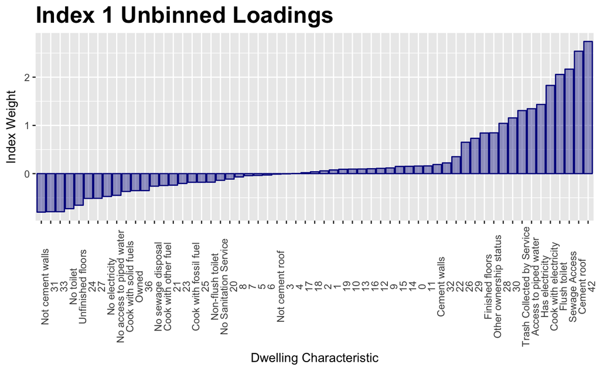

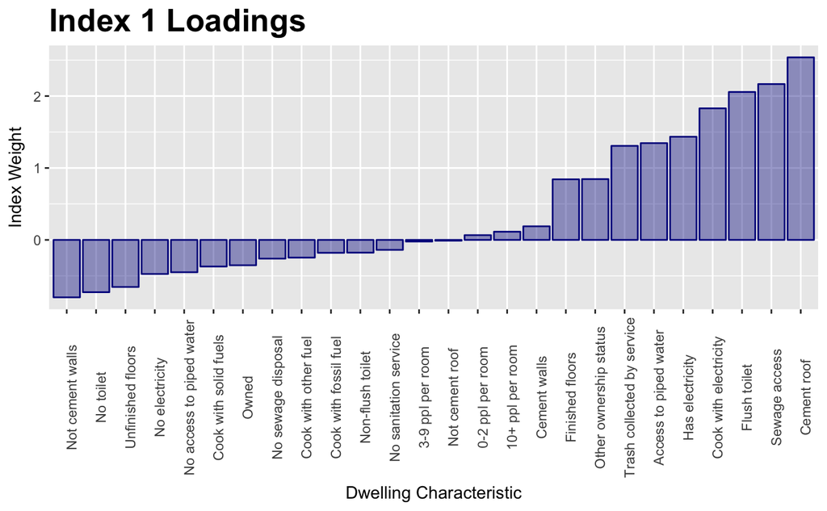

Index 2 unbinned and Index 2:

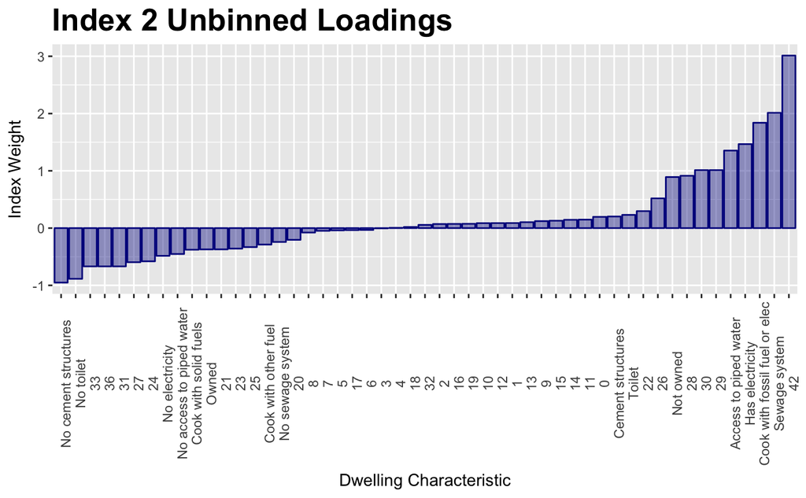

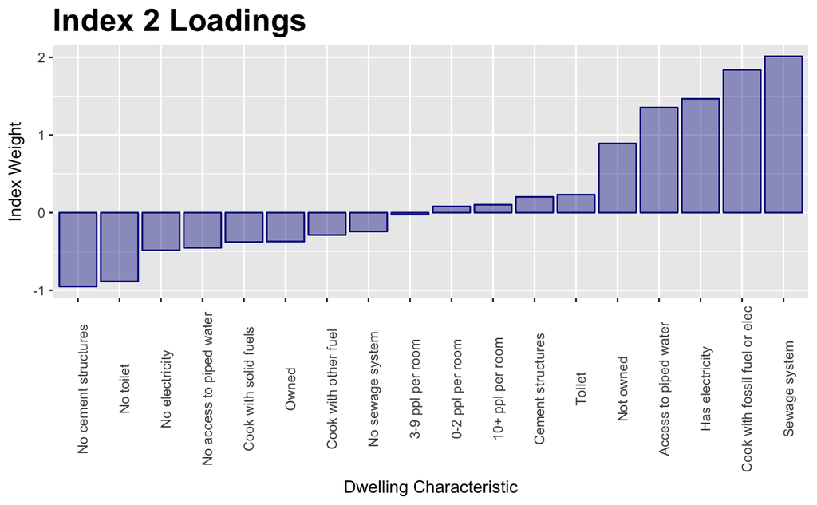

##### Comparing household scores

Household score for Index 1, 2 unbinned:

```r
#Index 1 unbinned
households_1.unbinned <- data.frame(country_1.mca.unbinned$ind$coord[,1])
households_1.unbinned$ID <- rownames(households_1.unbinned)
colnames(households_1.unbinned) <- c("score","ID")

#Index 2 unbinned
households_2.unbinned <- data.frame(country_2.mca.unbinned$ind$coord[,1])
households_2.unbinned$ID <- rownames(households_2.unbinned)
colnames(households_2.unbinned) <- c("score","ID")
```

[figure not shown]

### Comparing number.ppl.per.room.1 binned (as in Index 1) vs alternate binning (0-1, 2-4, 5-9, 10+)

Building the MCA models using “number of people per room” as binned above (Index 1, 2 altbin):

```r
country_1.sub.altbin = select(country_1, c(ownership.1,
                                      electric.1,
                                      water.supply.1,
                                      sewage.simple.1,
                                      #sewage.detailed.1,
                                      cooking.fuel.1,
                                      trash.1,
                                      #heat.1,
                                      #aircon.1,
                                      alt.bin.number.ppl.per.room.1,
                                      toilet.1,
                                      floor.1,
                                      wall.1,
                                      roof.1))

country_2.sub.altbin = select(country_2, c(ownership.1,
                                      electric.1,
                                      water.supply.1,
                                      sewage.general.1,
                                      cooking.fuel.1,
                                      alt.bin.number.ppl.per.room.1,
                                      toilet.1,
                                      dwelling.1))

country_1.mca.altbin = MCA(country_1.sub.altbin,row.w = country_1$Household.weight, graph = FALSE)
country_2.mca.altbin = MCA(country_2.sub.altbin,row.w = country_2$Household.weight, graph = FALSE)
```

##### Comparing Loadings

The plot of loadings for alternate binning of number.ppl.per.room.1 show that the index weights the levels similarly to our selected binning.  
Index 1 altbin and Index 1:

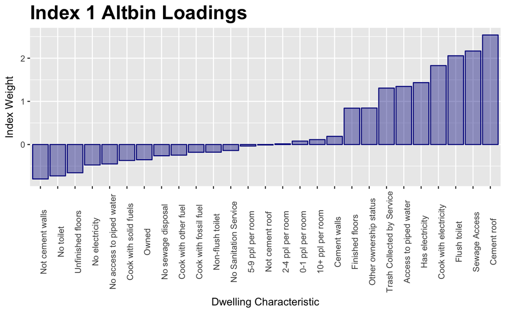

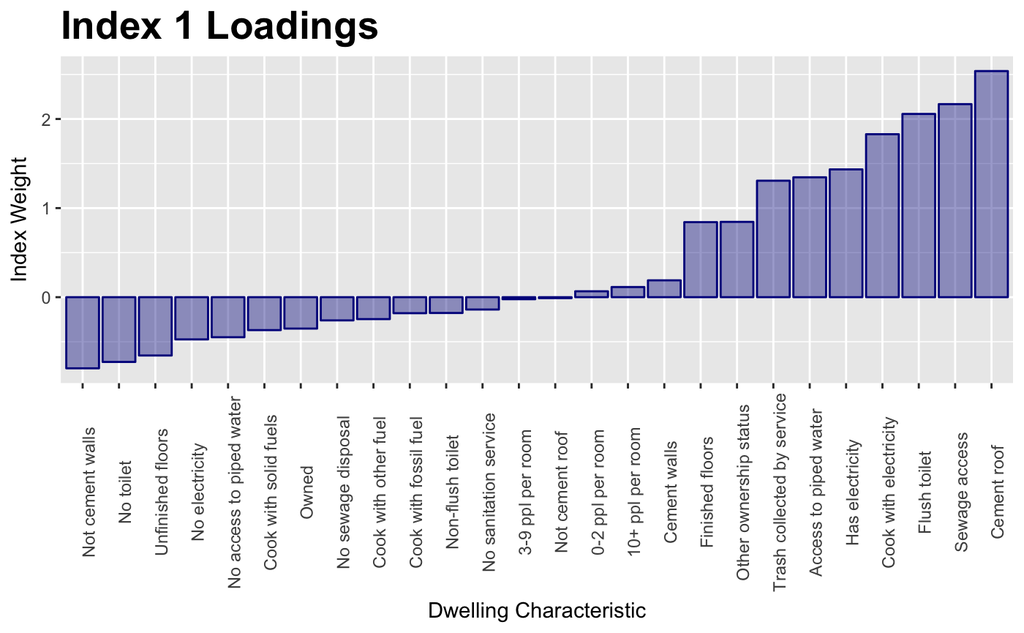

Index 2 altbin and Index 2:

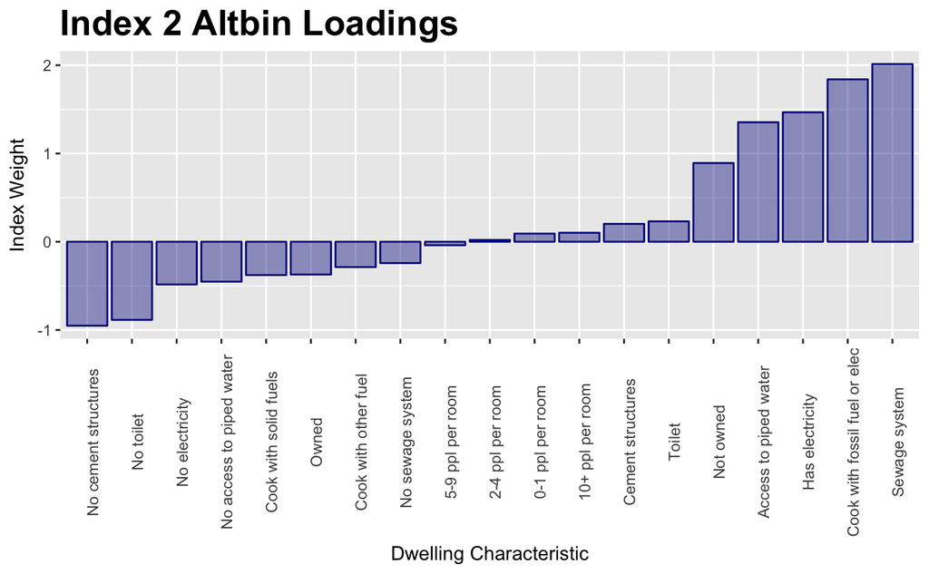

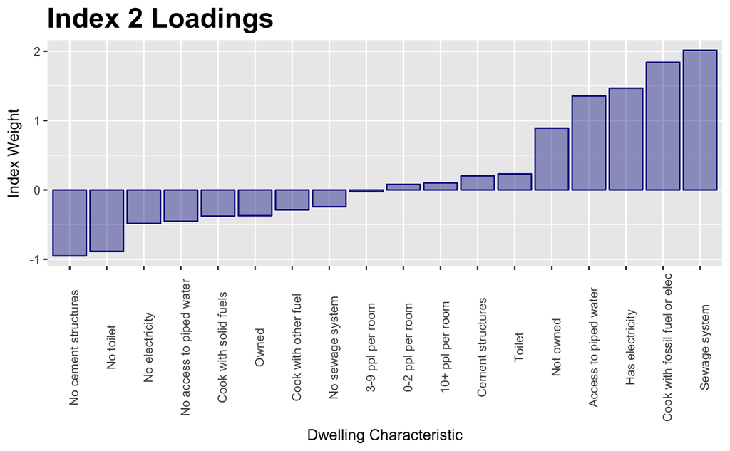

### Comparing Household Scores

Household scores for Index 1, 2 altbin:

```r
#Index 1, altbin
households_1.altbin <- data.frame(country_1.mca.altbin$ind$coord[,1])
households_1.altbin$ID <- rownames(households_1.altbin)
colnames(households_1.altbin) <- c("score","ID")

#Index 2, altbin
households_2.altbin <- data.frame(country_2.mca.altbin$ind$coord[,1])
households_2.altbin$ID <- rownames(households_2.altbin)
colnames(households_2.altbin) <- c("score","ID")
```

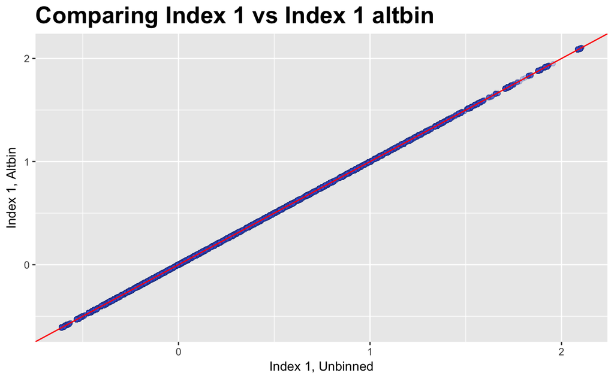

[figure not shown]

Plot of correlation between household score for binned vs Altbin Index 2:

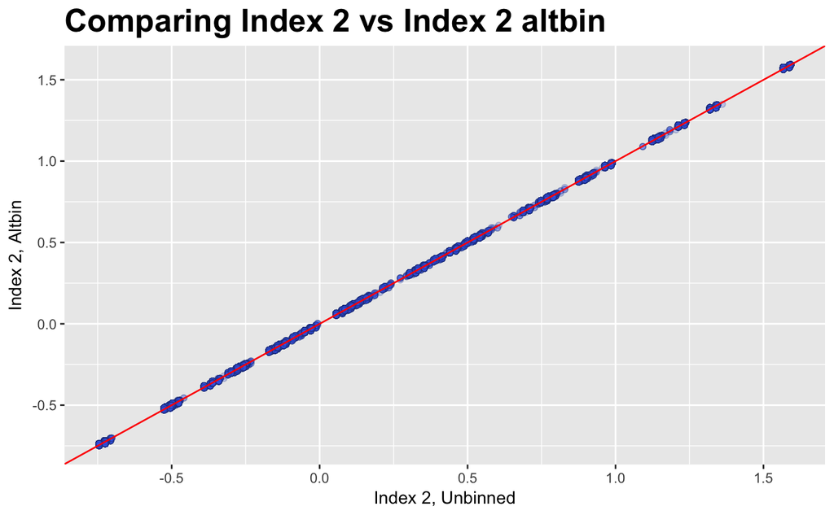

Plots of correlation between household score for Index 1 with alternate bining vs Index 1 unbinned, Index 2 with alternate binning vs Index 2 unbinned demonstrate that the two binning schemes hardly differ.  
Plot of correlation between household score for altbinned vs unbinned Index 1:

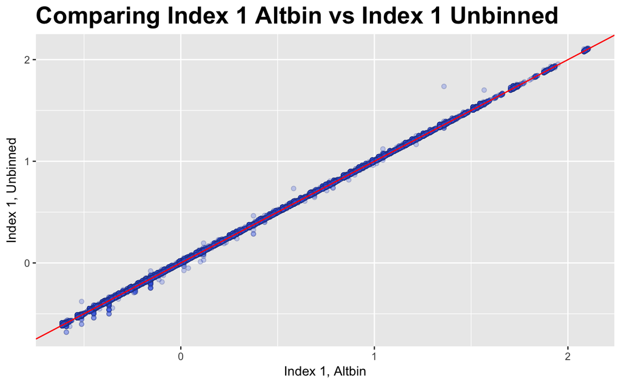

Plot of correlation between household score for altbinned vs unbinned Index 2:

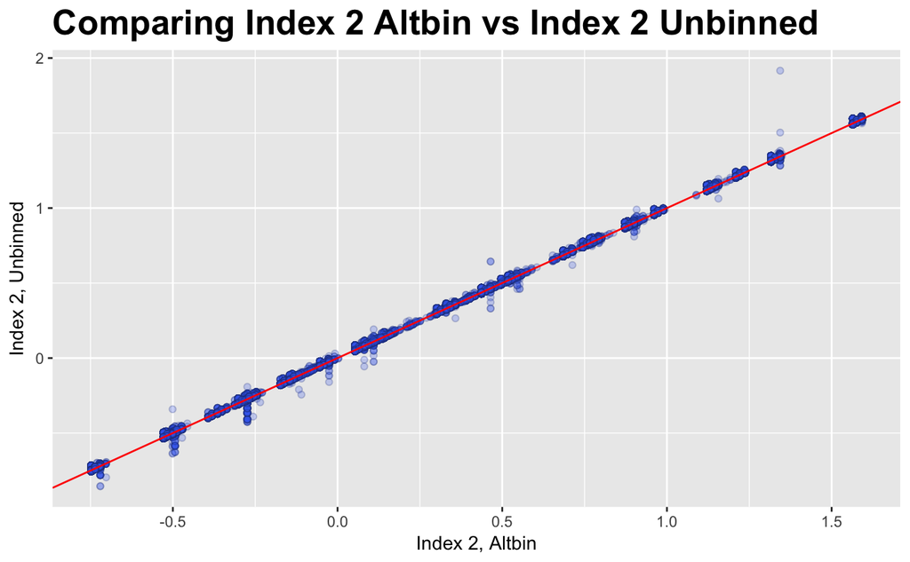